# Lab2-1

- babynames 패키지에 있는 데이터셋을 이용하여 데이터를 정제 및 시각화한다.
- 해당 데이터셋은 미국 SSA(Social Security Administration)의 공공데이터이다.
- 해당 데이터의 기준일은 2014년 1월 1일이다.

### 라이브러리 및 데이터 호출

```r
library(mdsr)
library(babynames)
library(dplyr)
library(ggplot2)
library(Hmisc)
BabynamesDist = make_babynames_dist()
head(BabynamesDist)
```

```
## # A tibble: 6 x 9
##    year sex   name      n   prop alive_prob count_thousands age_today
##   <dbl> <chr> <chr> <int>  <dbl>      <dbl>           <dbl>     <dbl>
## 1  1900 F     Mary  16707 0.0526          0           16.7        114
## 2  1900 F     Helen  6343 0.0200          0            6.34       114
## 3  1900 F     Anna   6114 0.0192          0            6.11       114
## 4  1900 F     Marg~  5304 0.0167          0            5.30       114
## 5  1900 F     Ruth   4765 0.0150          0            4.76       114
## 6  1900 F     Eliz~  4096 0.0129          0            4.10       114
## # ... with 1 more variable: est_alive_today <dbl>
```

### 자료형 확인

```r
str(BabynamesDist)
```

```
## Classes 'tbl_df', 'tbl' and 'data.frame':    1639490 obs. of  9 variables:
##  $ year           : num  1900 1900 1900 1900 1900 1900 1900 1900 1900 1900 ...
##  $ sex            : chr  "F" "F" "F" "F" ...
##  $ name           : chr  "Mary" "Helen" "Anna" "Margaret" ...
##  $ n              : int  16707 6343 6114 5304 4765 4096 3920 3896 3856 3414 ...
##  $ prop           : num  0.0526 0.02 0.0192 0.0167 0.015 ...
##  $ alive_prob     : num  0 0 0 0 0 0 0 0 0 0 ...
##  $ count_thousands: num  16.71 6.34 6.11 5.3 4.76 ...
##  $ age_today      : num  114 114 114 114 114 114 114 114 114 114 ...
##  $ est_alive_today: num  0 0 0 0 0 0 0 0 0 0 ...
```

### 데이터 전처리

```r
joseph = BabynamesDist %>%
  filter(name == 'Joseph', sex =='M')
```

- 전체 데이터에서 이름이 Joseph이고 성별이 남자인 사람만 추출한다.

```r
name_plot = ggplot(data = joseph, aes(x = year))
name_plot = name_plot +
  geom_bar(stat = "identity",
           aes(y = count_thousands * alive_prob),
           fill = "#b2d7e9",
           color="white")
```

- count_thousands와 alive_prob의 곱을 활용하여 이름이 joseph인 사람 중, 현재까지 생존해 있는 사람의 수를 막대그래프로 시각화한다.

```r
name_plot = name_plot +
  geom_line(aes(y = count_thousands), size=2) +
  ylab("Number of People (thousands)") +
  xlab(NULL)
```

- geom_line을 이용하여 변수 count_thousands의 값들을 선으로 표시한다.

```r
median_joseph =
  with(joseph, wtd.quantile(year, est_alive_today, probs = 0.5))
```

- est_alive_today를 weight로 하는 year의 중앙값을 확인

```r
name_plot = name_plot +
  geom_bar(stat = "identity",
           colour = "white",
           fill = "#008fd5",
           aes(y = ifelse(year == median_joseph, est_alive_today / 1000, 0)))
```

- 현재 살아 있는 joseph이 태어난 연도의 중앙값의 막대를 highlight한다.

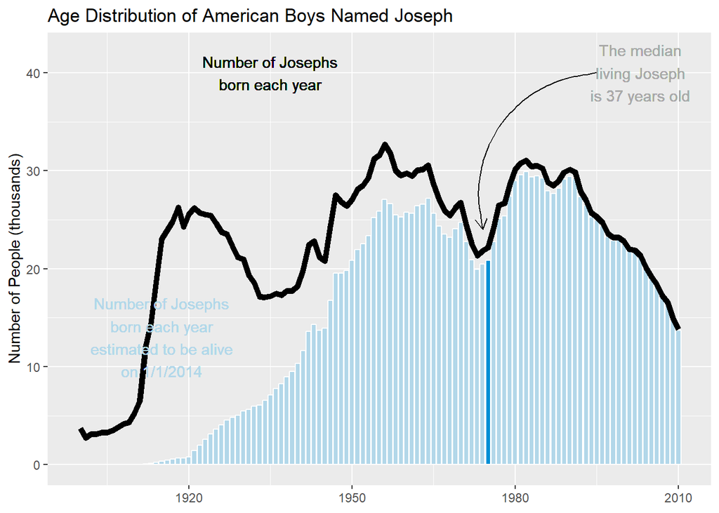

```r
name_plot +
  ggtitle("Age Distribution of American Boys Named Joseph") +
  geom_text(x = 1935, y = 40, label = "Number of Josephs\nborn each year") +
  geom_text(x = 1915, y = 13, label =
              "Number of Josephs\nborn each year\nestimated to be alive\non 1/1/2014",
            colour = "#b2d7e9") +
  geom_text(x = 2003, y = 40,
            label = "The median\nliving Joseph\nis 37 years old",
            colour = "darkgray") +
  geom_curve(x = 1995, xend = 1974, y = 40, yend = 24,
             arrow = arrow(length = unit(0.3,"cm")), curvature = 0.5) + ylim(0, 42)
```

- 검은색 실선은 각 연도에 태어난 joseph의 수를 1000으로 나눈 값이다.
- 하늘색 막대는 각 연도에 태어난 joseph 중 현재 살아 있을 것으로 추정되는 사람의 수를 1000으로 나눈 값이다.
- 당연한 말이지만, 과거로 갈 수록 태어난 수에 비해 생존한 수가 줄어들고, 최근 연도로 올수록 태어난 수와 생존한 수가 비슷해진다.

### %+% Operator

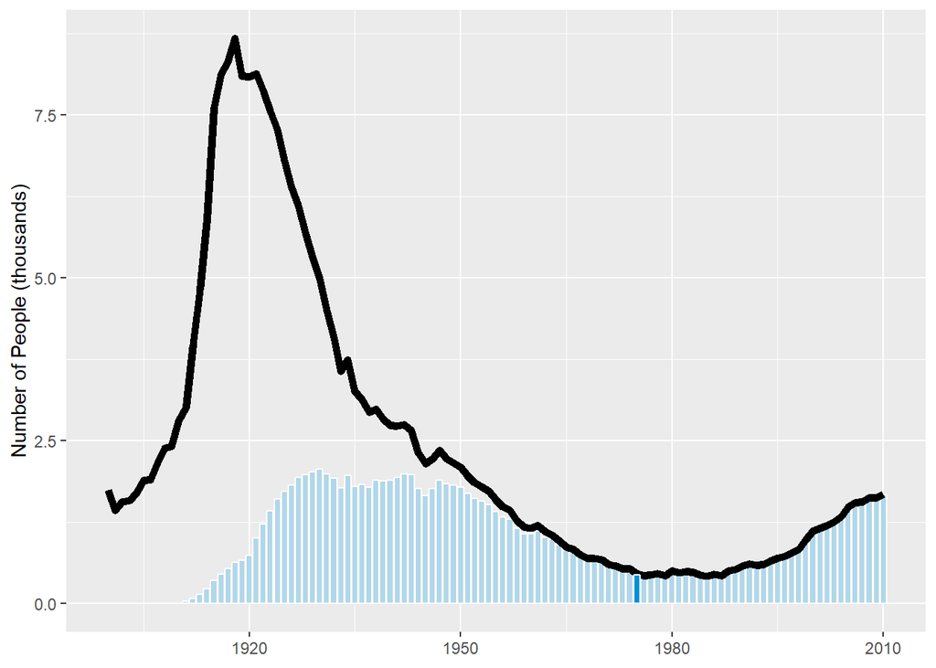

```r
Josephine = filter(BabynamesDist, name == "Josephine" & sex == "F")
name_plot %+% Josephine
```

- %+% 연산자를 통해 위의 그래프를 joseph이 아닌 다른 이름으로 그리는 것을 훨씬 쉽게 할 수 있다.
- 위 그래프는 joseph을 통해 그린 그래프를 josephine을 기준으로 그리도록 한 번에 바꿔준다.
- josephine이라는 이름은 요즘보다는 1900년대 초에 더 많이 쓰였던 이름임을 알 수 있다.

### facet_grid()

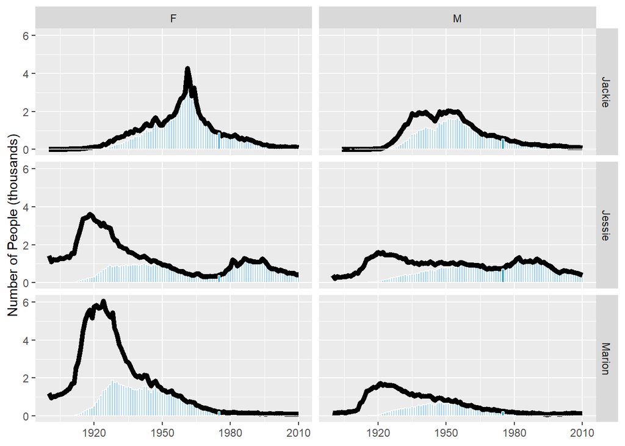

```r
many_names_plot = name_plot + facet_grid(name ~ sex)
mnp = many_names_plot %+%
  filter(BabynamesDist, name %in% c("Jessie", "Marion", "Jackie"))
mnp
```

- facet_grid와 %+% 연산자를 통해 여러 개의 이름을 성별로 나눠서 위와 동일한 그래프를 그릴 수도 있다.
- 여기서 filter의 데이터를 BabynamesDsit라고 한 이유는 name_plot에서 이미 남자의 데이터만 가져오라고 했기 때문에 더 이전의 데이터가 필요하기 때문이다.